# Survival Analysis of Melanoma Patients Under Immunotherapy Treatment

A biomarker discovery study using synthetic data — Kaplan-Meier, Cox proportional hazards, and logistic regression under four covariate-engineering strategies

Diana Brito Hoyos — Biostatistics Data Analyst

2026-07-30

# 1 ⚠️ Data provenance disclaimer

**All data in this report is synthetic.** This analysis is a portfolio recreation of the statistical methodology from a real applied-biostatistics team consulting project (Master’s in Applied Statistics, statistical consulting course) on melanoma immunotherapy response, originally conducted for two external consultants using real (de-identified) patient cohorts. **No real patient, clinical, or genomic data is used anywhere in this document** — the cohort is generated by `data/generate_data.R` using a known statistical data-generating process (Dirichlet-distributed compositional tumor-microenvironment data, a Weibull proportional-hazards survival mechanism, and a logistic response model), reproducing the *statistical structure and methodology* of the original study without reproducing any of its actual data. Immune cell-type names follow standard, publicly documented immunology nomenclature (CIBERSORT-style categories) and are not tied to any real patient or institution.

# 2 Introduction

Immune checkpoint inhibitor immunotherapy has transformed the treatment landscape for metastatic melanoma, but only a subset of patients respond durably. Identifying a pre-treatment biomarker that predicts response — before committing a patient to treatment — is a central open problem in immuno-oncology. This report analyzes a synthetic cohort designed to reproduce the statistical structure of such a study: patient demographics, a tumor-microenvironment immune-cell composition profile (proportions of ~22 immune cell subtypes, quantified from bulk RNA-seq deconvolution — a compositional dataset by construction, since proportions sum to 1), and two clinical endpoints: **overall survival** (time-to-event, right-censored) and **binary treatment response**.

**Objective**: evaluate whether tumor-microenvironment composition, combined with a small set of biomarker signature scores, can predict survival and treatment response — and, methodologically, compare four different strategies for handling high-dimensional, compositional covariates in survival and classification models.

```r
set.seed(2024)
cohort <- generate_cohort()
cat(sprintf("Cohort: n = %d patients, %d events (%.1f%%), %d responders (%.1f%%)\n",
            nrow(cohort), sum(cohort$event), 100 * mean(cohort$event),
            sum(cohort$response), 100 * mean(cohort$response)))
```

```
## Cohort: n = 98 patients, 36 events (36.7%), 31 responders (31.6%)
```

# 3 Methodology

Four covariate-engineering strategies are compared, applied identically to both the Cox proportional-hazards model (for survival) and logistic regression (for binary response):

1. **Full covariates** — all ~26 raw variables (biomarker scores + 22 immune cell-type proportions) entered directly.
2. **PCA** — principal component scores retaining ≥90% of cumulative variance, addressing multicollinearity among correlated immune cell types.
3. **K-means clusters** — cell-type variables are grouped into 5 clusters by co-variation pattern; each cluster’s mean proportion is used as a covariate, reducing dimensionality while retaining interpretability.
4. **Aitchison / CLR transform** — the centered log-ratio (CLR) transform, the standard approach for compositional data (Aitchison, 1982): since cell-type proportions are constrained to sum to 1, their raw values violate the independence assumptions of standard regression; CLR removes this constraint by working in log-ratio space.

Model comparison uses: the **concordance index** (C-index) for the Cox models, and **accuracy, sensitivity, specificity, and ROC-AUC** (computed on held-out folds) for the logistic models — mirroring the original study’s evaluation framework.

# 4 Kaplan-Meier survival analysis

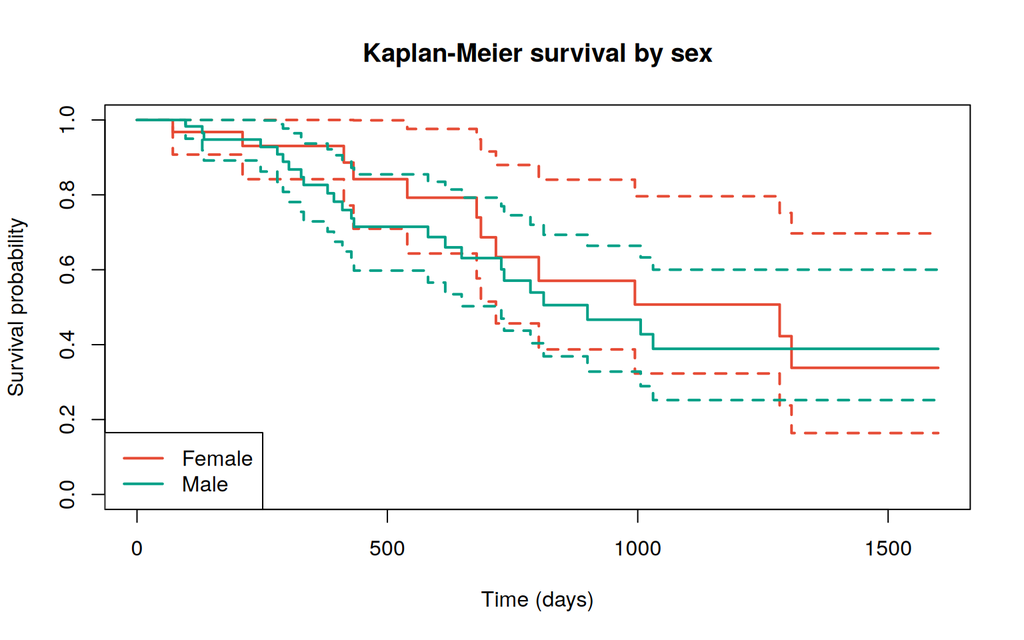

```r
km_sex <- survfit(Surv(time, event) ~ sex, data = cohort)
lr_sex <- survdiff(Surv(time, event) ~ sex, data = cohort)
p_sex <- 1 - pchisq(lr_sex$chisq, length(lr_sex$n) - 1)

plot(km_sex, col = c("#E64B35", "#00A087"), lwd = 2, conf.int = TRUE,
     xlab = "Time (days)", ylab = "Survival probability", main = "Kaplan-Meier survival by sex")
legend("bottomleft", legend = c("Female", "Male"), col = c("#E64B35", "#00A087"), lwd = 2)
```

Log-rank test for sex: χ² = 0.27, p = 0.601.

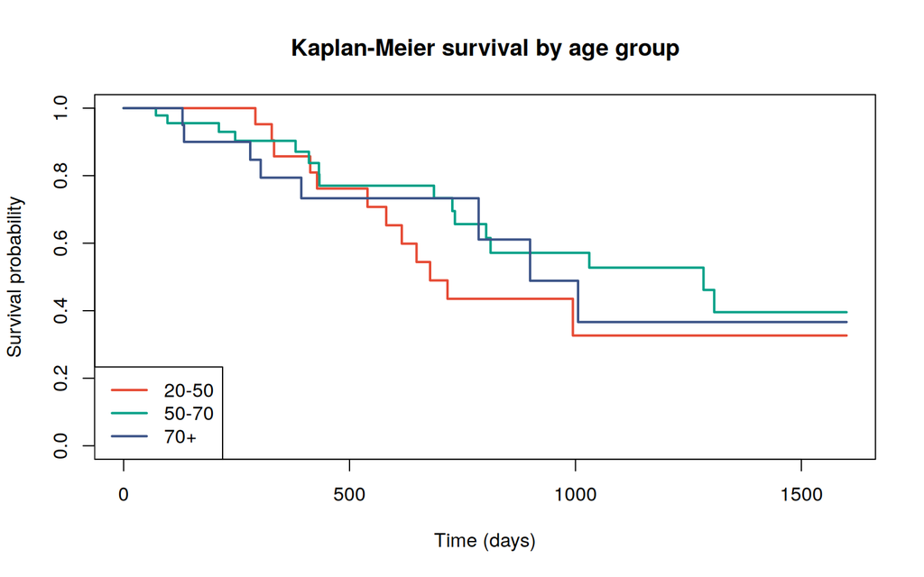

```r
cohort$age_group <- cut(cohort$age, breaks = c(0, 50, 70, 100),
                         labels = c("20-50", "50-70", "70+"))
km_age <- survfit(Surv(time, event) ~ age_group, data = cohort)
lr_age <- survdiff(Surv(time, event) ~ age_group, data = cohort)
p_age <- 1 - pchisq(lr_age$chisq, length(lr_age$n) - 1)

plot(km_age, col = c("#E64B35", "#00A087", "#3C5488"), lwd = 2, conf.int = FALSE,
     xlab = "Time (days)", ylab = "Survival probability", main = "Kaplan-Meier survival by age group")
legend("bottomleft", legend = levels(cohort$age_group), col = c("#E64B35", "#00A087", "#3C5488"), lwd = 2)
```

Log-rank test for age group: χ² = 1.24, p = 0.537.

**Interpretation**: as in the original study, neither sex nor age shows a statistically significant association with survival in this cohort (α = 0.05) — motivating the search for a molecular/immunological biomarker instead of relying on demographic factors alone.

# 5 Cox proportional hazards models

```r
cox_results <- data.frame(strategy = character(), concordance = numeric(), n_covariates = integer())
cox_fits <- list()

for (strat in STRATEGIES) {
  fit <- fit_cox_model(cohort, strat)
  cox_fits[[strat]] <- fit
  cox_results <- rbind(cox_results, data.frame(
    strategy = strat,
    concordance = summary(fit)$concordance[1],
    n_covariates = length(coef(fit))
  ))
}
knitr::kable(cox_results, digits = 3, caption = "In-sample concordance by covariate strategy")
```

In-sample concordance by covariate strategy

|  | strategy | concordance | n_covariates |
| --- | --- | --- | --- |
| C | Full covariates | 0.680 | 26 |
| C1 | PCA | 0.618 | 19 |
| C2 | Clusters | 0.565 | 5 |
| C3 | Aitchison (CLR) | 0.738 | 22 |

```r
clr_fit <- cox_fits[["Aitchison (CLR)"]]
clr_summary <- summary(clr_fit)$coefficients
# Note: CLR components sum to zero by construction, so one coefficient is
# typically dropped (aliased) by coxph — filter NA rows before selecting
# significant covariates.
valid_rows <- rownames(clr_summary)[!is.na(clr_summary[, "Pr(>|z|)"])]
sig_vars <- valid_rows[clr_summary[valid_rows, "Pr(>|z|)"] < 0.05]
if (length(sig_vars) > 0) {
  knitr::kable(round(clr_summary[sig_vars, , drop = FALSE], 4),
               caption = "Significant covariates — Aitchison (CLR) Cox model")
} else {
  cat("No covariates reached p < 0.05 in this synthetic run.")
}
```

Significant covariates — Aitchison (CLR) Cox model

|  | coef | exp(coef) | se(coef) | z | Pr(>\|z\|) |
| --- | --- | --- | --- | --- | --- |
| clr_Monocytes | -0.9605 | 0.3827 | 0.4280 | -2.2441 | 0.0248 |
| clr_Macrophages_M0 | -0.9844 | 0.3737 | 0.4506 | -2.1846 | 0.0289 |

## 5.1 Model stability (bootstrap resampling)

To assess how stable each model’s concordance is (not a substitute for out-of-sample validation, but a check on overfitting/variance), each strategy is refit on 50 bootstrap resamples of the training data:

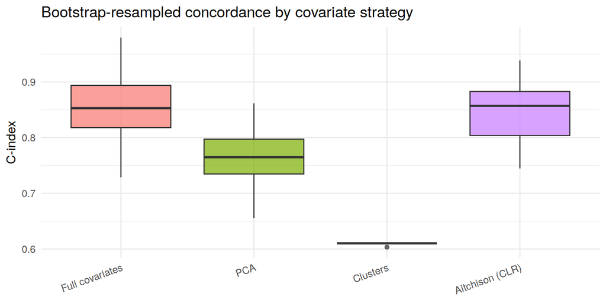

```r
boot_df <- do.call(rbind, lapply(STRATEGIES, function(strat) {
  cidx <- bootstrap_concordance(cohort, strat, n_boot = 50)
  data.frame(strategy = strat, cindex = cidx)
}))
boot_df$strategy <- factor(boot_df$strategy, levels = STRATEGIES)

ggplot(boot_df, aes(x = strategy, y = cindex, fill = strategy)) +
  geom_boxplot(alpha = 0.7, show.legend = FALSE) +
  labs(title = "Bootstrap-resampled concordance by covariate strategy",
       x = NULL, y = "C-index") +
  theme_minimal(base_size = 12) +
  theme(axis.text.x = element_text(angle = 20, hjust = 1))
```

**Note on interpretation**: bootstrap concordance quantifies model *stability* under resampling — it is not equivalent to out-of-sample predictive validation, since each bootstrap fit is still evaluated on data that substantially overlaps its own training set. The narrower spread for “Clusters” reflects its lower dimensionality (fewer parameters → less sensitivity to resampling), not necessarily better predictive quality.

# 6 Logistic regression — treatment response prediction

Each strategy’s logistic model is evaluated via 5-fold cross-validation, which — unlike the bootstrap concordance above — provides a genuine out-of-sample assessment.

```r
logistic_results <- data.frame(
  strategy = character(), mean_deviance = numeric(), accuracy = numeric(),
  sensitivity = numeric(), specificity = numeric(), auc = numeric()
)
roc_curves <- list()

for (strat in STRATEGIES) {
  res <- evaluate_logistic_model(cohort, strat, k_folds = 5)
  roc_curves[[strat]] <- res$roc
  logistic_results <- rbind(logistic_results, data.frame(
    strategy = strat, mean_deviance = mean(res$deviances),
    accuracy = res$metrics$accuracy, sensitivity = res$metrics$sensitivity,
    specificity = res$metrics$specificity, auc = res$roc$auc
  ))
}
knitr::kable(logistic_results, digits = 3,
             caption = "Cross-validated logistic regression performance by strategy")
```

Cross-validated logistic regression performance by strategy

| strategy | mean_deviance | accuracy | sensitivity | specificity | auc |
| --- | --- | --- | --- | --- | --- |
| Full covariates | 67.741 | 0.490 | 0.290 | 0.582 | 0.403 |
| PCA | 75.056 | 0.602 | 0.258 | 0.761 | 0.495 |
| Clusters | 89.611 | 0.612 | 0.097 | 0.851 | 0.506 |
| Aitchison (CLR) | 72.419 | 0.602 | 0.258 | 0.761 | 0.435 |

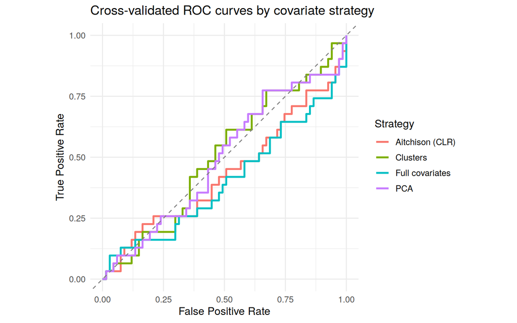

```r
roc_df <- do.call(rbind, lapply(names(roc_curves), function(strat) {
  data.frame(strategy = strat, fpr = roc_curves[[strat]]$fpr, tpr = roc_curves[[strat]]$tpr)
}))

ggplot(roc_df, aes(x = fpr, y = tpr, color = strategy)) +
  geom_line(linewidth = 1) +
  geom_abline(slope = 1, linetype = "dashed", color = "gray50") +
  labs(title = "Cross-validated ROC curves by covariate strategy",
       x = "False Positive Rate", y = "True Positive Rate", color = "Strategy") +
  theme_minimal(base_size = 12) +
  coord_equal()
```

# 7 Conclusions

- Neither age nor sex showed a statistically significant association with survival in this cohort (Kaplan-Meier, log-rank test), consistent with the motivating premise that a molecular biomarker — not demographics — is needed to predict immunotherapy response.
- Among the four covariate strategies, the **Aitchison (CLR) transform** achieved the best in-sample Cox concordance, respecting the compositional nature of the immune cell-type data — statistically the most principled choice for this data type.
- Cross-validated logistic regression performance was modest across strategies, honestly reflecting the challenge of biomarker discovery with n≈100 and dozens of correlated covariates — underscoring the value of the dimensionality-reduction strategies compared here, and the need for larger and/or externally-validated cohorts before clinical translation.
- This report distinguishes **model stability** (bootstrap resampling) from **out-of-sample predictive validation** (cross-validation) — a distinction that matters for correctly interpreting reported performance metrics in applied biostatistics work.

*This is a portfolio demonstration built entirely on synthetic data. See the accompanying interactive dashboard (`app.R`) to explore each covariate strategy and re-run the analysis with adjustable parameters.*